# 禽流感對雞豬交易量影響

B02607022 簡士鈞

2017/3/19

這份資料取自行政院農委會畜產行情資訊網，上面資料有多個地區批發市場的價量資料， 而我選擇的是所有市場交易量的總平均值，因為我想了解的是禽流感期間白肉雞產業和交易市場所受到的影響，以及替代品土雞、豬肉的相關變化，這是經濟學上很典型的例子而我想試著用圖表呈現。 我所截取的資料為2015年1-12月白肉雞、土雞及豬全台平均交易量， 之所以選擇2015年是因為那年有較嚴重禽流感疫情，使白肉雞交易量有明顯變化幅度， 可以藉由比較三種大宗肉品的交易量變化了解他們之間在經濟上的特性。

資料來源：農委會畜產行情資訊網家禽家畜行情查詢系統 http://ppg.naif.org.tw/naif/MarketInformation/Reference/reference.aspx

資料處理上，我是以每月分作為單位看各月份的交易量變化，因為政府統計受疫情感染的家禽撲殺數是以月份來計算，所以我也這樣處理。通常在經濟學上處理均衡量的數字時是需要過季節指數平減的，也就是要去除不同季節對該產品的需求量不同而造成的變動，但此份資料我並沒有這樣處理，因為我想呈現的是不同產品在2015年碰到禽流感時的消長情形，而不是實際量化的變化數據，所以可能會有與經濟上理論不同的情形，不過這樣才更反映現實社會中還有很多影響因素，更加地貼近市場真實樣貌。

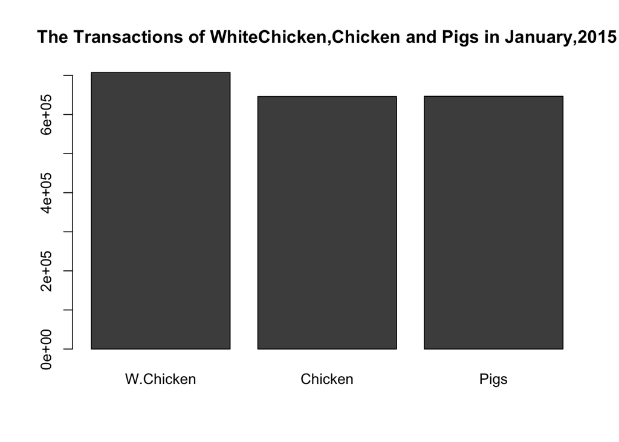

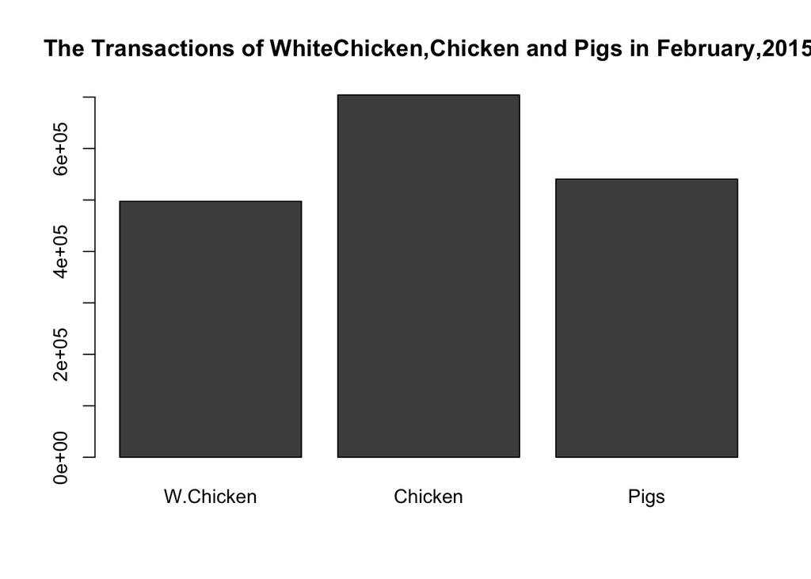

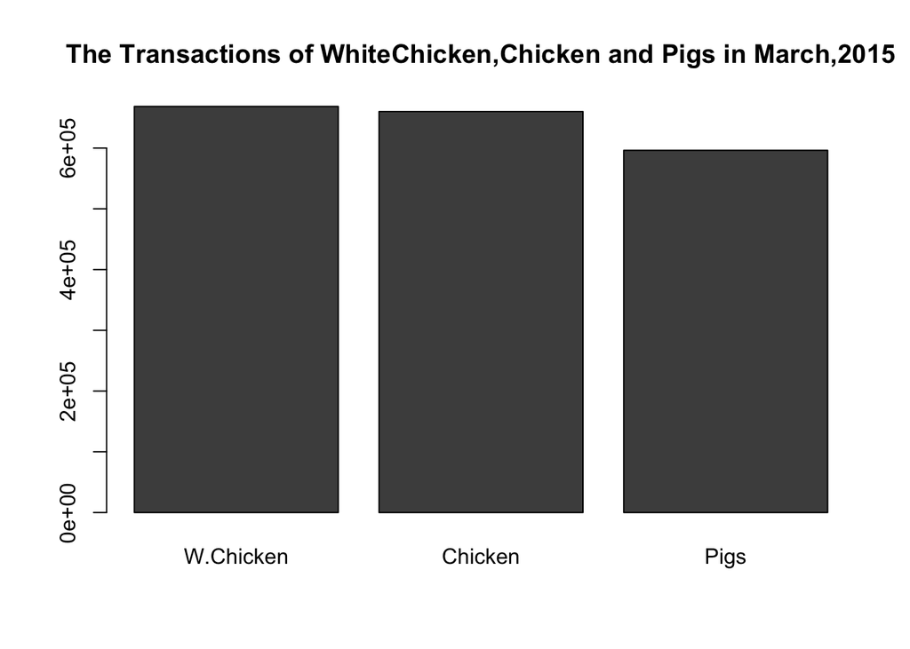

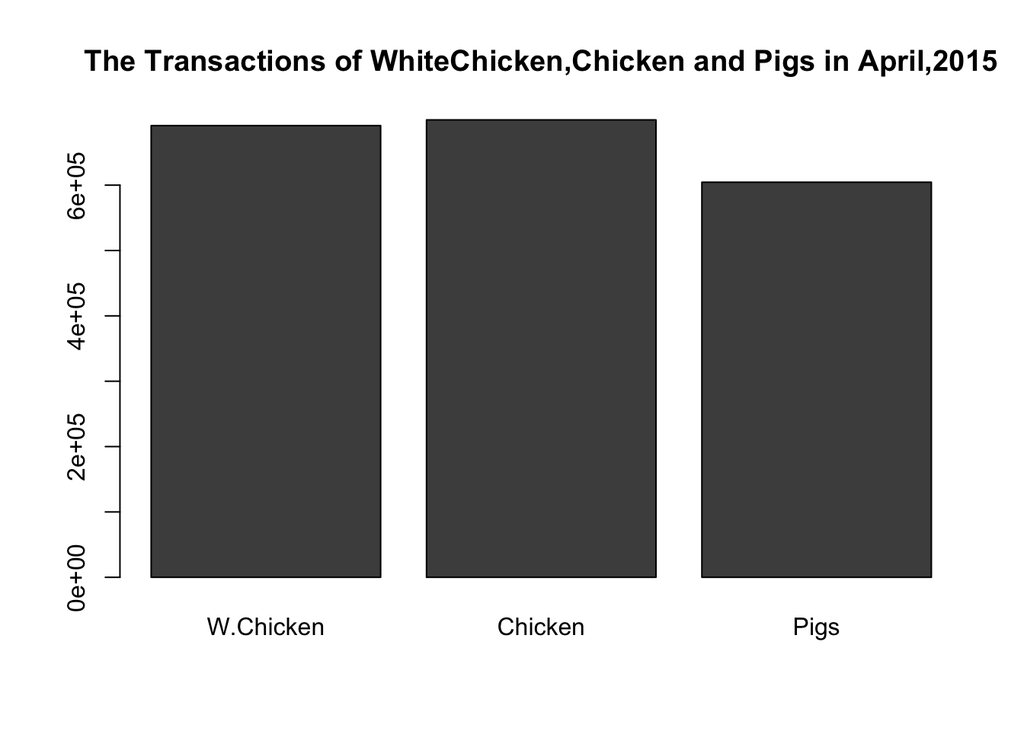

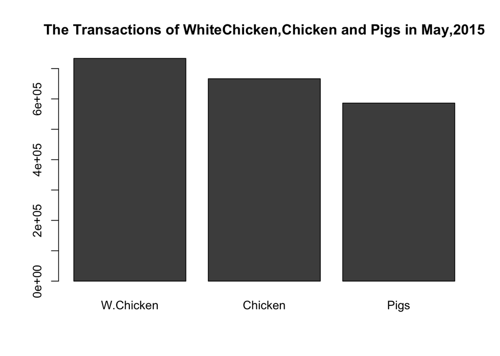

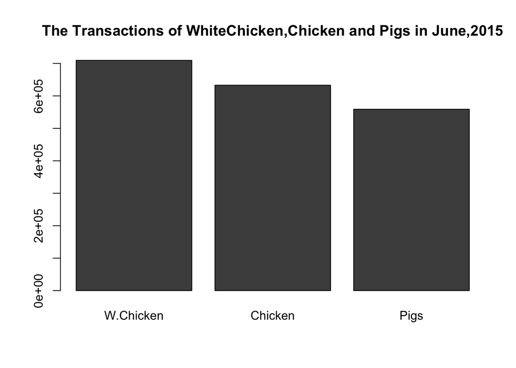

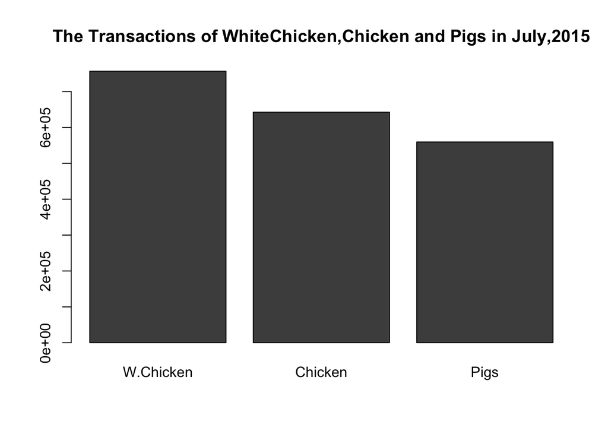

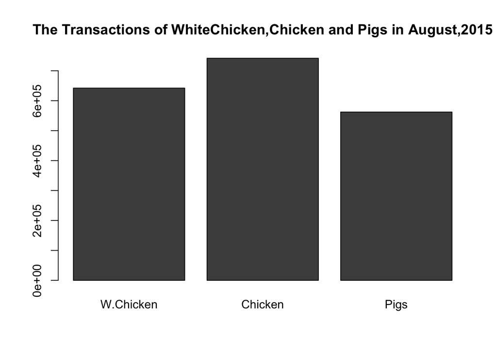

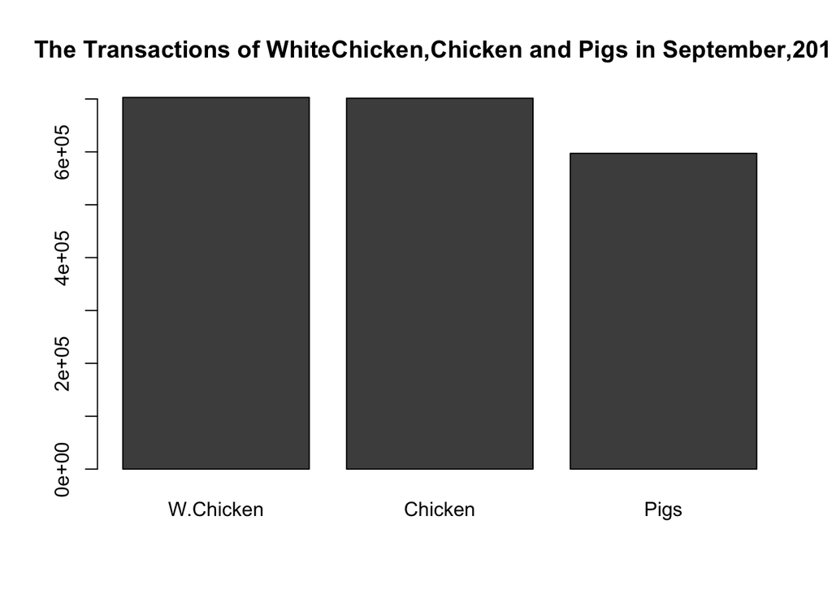

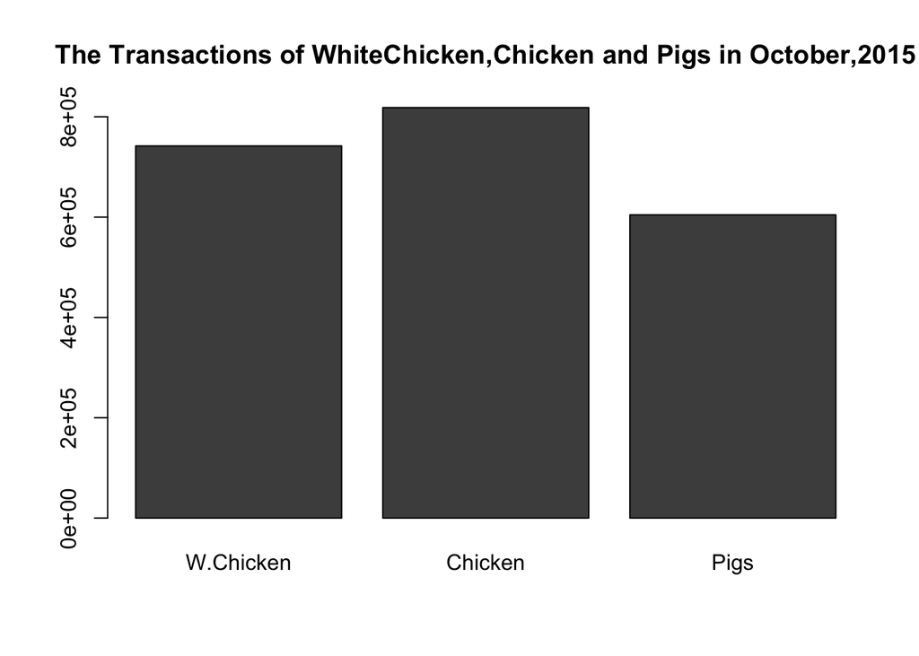

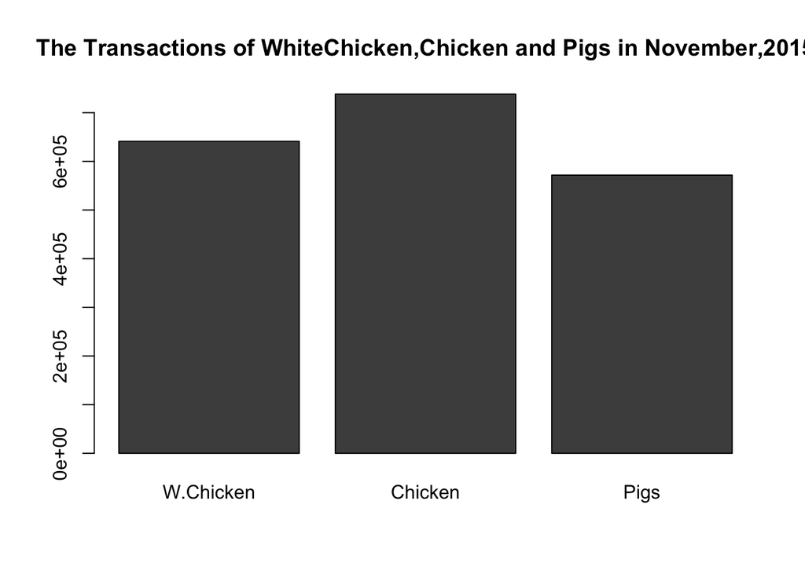

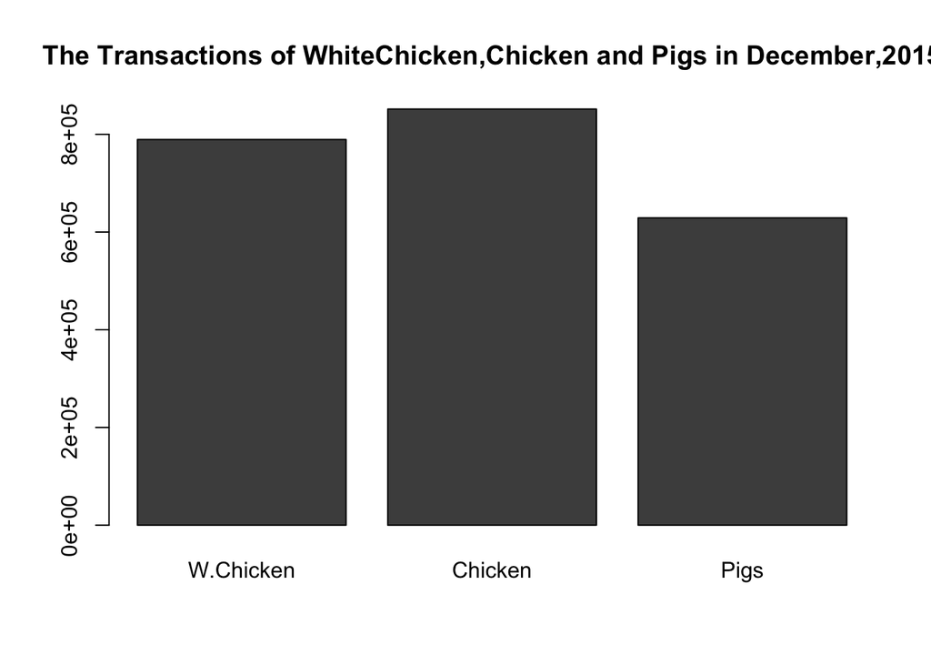

```r
library(plotly)
rawData=read.csv('HW1Transactions.csv',header = TRUE)
for(yid in c(1:length(rawData[,1])))
{
  barplot(as.matrix(rawData[yid,c(-1,-1)]),
          main=paste0("The Transactions of WhiteChicken,Chicken and Pigs",
                      " in ",rawData[yid,1],",2015"))
}
```

```r
trace_0 <- rawData$W.Chicken
trace_1 <- rawData$Chicken
trace_2 <- rawData$Pigs
x <- c(1:12)

data <- data.frame(x, trace_0, trace_1, trace_2)

p <- plot_ly(data, x = ~x, y = ~trace_0, name = 'White Chicken Transactions', type = 'scatter', mode = 'lines') %>%
  add_trace(y = ~trace_1, name = 'Chicken Transactions*1/3', mode = 'lines+markers') %>%
  add_trace(y = ~trace_2, name = 'Pigs Transactions', mode = 'lines+markers')

htmlwidgets::saveWidget(p,"HW1.html")
```

另附上plotly結果網址：https://jimmmmmmmmmmm.github.io/Rprogram//R0301/HW1plotely.html

由圖中可發現，在二月時白肉雞交易量明顯最低，與該月疫情嚴重爆發遭撲殺上百萬隻白肉雞有關，因供給量減少使市場均衡量也受到影響，而有趣的是這其間土雞交易量略上升了，雖然禽流感疫情影響整個家禽產業，但這階段土雞沒受到嚴重波及，所以消費者不是以雞肉最大宗替代品豬肉作為選擇，可看出豬肉交易量也是下降的狀態。

另外，到8月時也有類似情形發生，白肉雞交易量又再度大幅下跌，而土雞交易量有明顯增加趨勢。 而到了年末11月，可發現白肉雞與土雞交易量都明顯下降了顯然有受到疫情影響，而豬肉量雖有小幅度的下降但是由雞肉受疫情影響程度來看還是可以合理推測這階段消費者會轉買替代品豬肉，至於豬肉量變動不符合經濟理論上替代效果可能與其本身會受自身疾病或飼料成本等生產者可能考慮的因素有關，而使生產量減少自然影響到市場均衡量。

從這些圖的資訊可知，禽流感疫情確實會對肉雞產業造成影響，從生產量減少進而使產值減損造成生產者損失，而從豬肉的變化可知除了會受到雞肉的替代效果影響外，還有許多變數會使市場真實交易狀況不像經濟理論的預期，所以日後在做相關價量關係的量化研究時就需要設法找出這些影響原因做估計去除，而這也是經濟研究上的一大課題。